# QTM 151 - Practice Quiz

**Submit as an HTML file** (see images below)

Step 1: Click the 3 dots in the toolbar for "More Actions"

[figure not shown]

Step 2: Choose "export"

[figure not shown]

Step 3: Select "HTML" from the dropdown window

[figure not shown]

Step 4: Select "Export" in the pop-up window.

[figure not shown]

Upload the .html file as your submission

Print your name below

```python
# Write your answer here

print("Gabe Vu")
```

```
Gabe Vu
```

This quiz is open book

- You can use the lecture notes
- You will get partial credit for attempting the questions
- To get full credit, the code should work as intended
- You should NOT communicate with other students

Print the following message:

"I will abide by Emory's code of conduct"

```python
# Write your answer here:
print("I will abide by Emory's code of Conduct")
```

```
I will abide by Emory's code of Conduct
```

(a) Checking If a Word is Part of a List

- Define a variable `topping1` with the value "mushrooms"
- Define a variable `topping2` with the value "pineapple"
- Define a list of pizza toppings with the values "cheese", "mushrooms", "pepperoni", and "onions"
- Write expressions to test whether `topping1` and `topping2` are contained in `pizza_toppings`  
  and print the outputs
- To get full points you must do all of the above tasks

Hint: Use the "in" command. The final output should be 2 True/False values.

```python
topping1 = "mushrooms"
topping2 = "pineapple"
pizza_toppings = ["cheese", "mushrooms", "pepperoni", "onion"]
print(topping1 in pizza_toppings) #The in function will check if the variable is in the list
print(topping2 in pizza_toppings)
```

```
True
False
```

(b) Threshold testing a sum

- Create a numeric vector (**"vector" always means Numpy array**), $ c = \begin{bmatrix} 1 \\ 2 \\ 3 \end{bmatrix} $
- Use the "numpy.sum()"' function to add up the individual elements.
- If the sum of numbers is higher than $5$, write a message saying  
  " The sum is greater than or equal to 5"
- Otherwise show a message "It is strictly less than 5"

```python
import numpy as np
vector = np.array([1, 2, 3])
np.sum(vector)
if np.sum(vector) > 5:
    print("The sume is greater than 5")
else:
    print("It is strictly less than 5")
```

```
The sume is greater than 5
```

### c) For-loops + Plotting

- Create an array of x-values with 100 evenly spaced points between $0$ and $2\pi$  
  using `np.linspace()`. **Hint**: type `help(np.linspace)` in a separate cell to see how it is used
- Create a vector named `vec_y1` where each element is computed from the formula  
  $ y_k = \sin(x_k)$. (Here $x_k$ is the $k$-th element of the array you created above, and $y_k$ is the $k$-th element of vec_y1)
- Create a vector `vec_y2` where each element is computed from the formula  
  $ y_k = \cos(x_k)$.
- Create a list `list_vectors` with elements `vec_y1` and `vec_y2`. (So a list with two components, both being numpy arrays)
- Create a for-loop that goes through each element of `list_vectors` and plots each  
  list of $y$ values on the vertical axis against $x$ on the horizontal axis.

Note: The final output should be a 2-dimensional plot with the values from vec_y1 and vec_y2 on the vertical axis, and the $x$ values on the horizontal axis. **Remember to label the axes and add a title to the plot**.

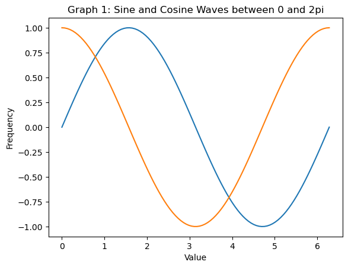

```python
# Write your answer here:
import numpy as np
import matplotlib.pyplot as plt
x_values = np.linspace(0, 2*np.pi, 100)
vec_y1 = np.sin(x_values)
vec_y2 = np.cos(x_values)
list_vectors = [vec_y1, vec_y2]

for vector in list_vectors:
    plt.plot(x_values, vector)

plt.title("Graph 1: Sine and Cosine Waves between 0 and 2pi")
plt.xlabel("Value")
plt.ylabel("Frequency")
plt.show()
```

(d) Creating a scatter plot

Using NumPy arrays, create a scatter plot of the function

$q(x) = \sin(\pi x) + 1$

at a set of points in the interval $0 \leq x \leq 2$

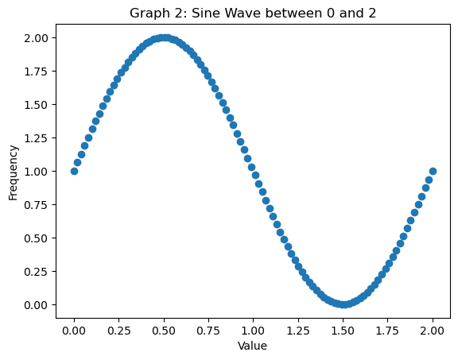

```python
x_values = np.linspace(0, 2, 100)

def practice_quiz_function(x):
    return np.sin(np.pi*x) + 1 #returns values between 0 and 2

y_values = practice_quiz_function(x_values)

plt.scatter(x = x_values, y = y_values)
plt.title("Graph 2: Sine Wave between 0 and 2")
plt.xlabel("Value")
plt.ylabel("Frequency")
plt.show()
```

(e) Open the dataset "united_states_co2_emissions.csv" in the "practice_quiz_data" folder using pandas

- Assign it to a variable named "us_emissions"
- Note: This contains CO2 emissions (in kilotons) by the United States from 1960-2019.  
  It is compiled from various sources, including the United Nations Framework Convention  
  on Climate Change (UNFCCC) and the International Energy Agency (IEA).

```python
# Write your answer here:
import pandas as pd

us_emissions = pd.read_csv("practice_quiz_data/united_states_co2_emissions.csv")
```

[output not shown]

(f) View the dataset and create a list of variable names

- The us_emissions dataset has two named column headings.
- Create a list containing two strings, one for each of the column headings.
- The strings must match the headings **exactly** (the "#" symbols shown in DataWrangler are not part of the name). Otherwise you will run into a problem in part d)
- Assign this list to a variable called "columns"
- You do not have to "extract" the names from the dataset through a Python command. You can simply type them manually.

```python
# Write your answer here:

columns = ["year", "total_emissions"]
```

Use an if/elif/else block to test whether a string belongs to one of two lists. Depending on the outcome (belongs to list A, belongs to list B, doesn't belong to either list) print an appropriate message to the screen.

```python
#answer here:

#Define the list
list_A = ["green_labubu", "blue_labubu", "red_labubu", "yellow_labubu"]
list_B = ["orange_labubu", "brown_labubu", "black_labubu", "white_labubu"]

#Define the variable we'll check
my_labubu = "green_labubu"

#Check which list the variable is in
if (my_labubu in list_A):
    print("Bruh my Labubu is in List A.")
elif (my_labubu in list_B):
    print("Bruh my Labubu is in List B.")
else:
    print("Bruh my Labubu is not in either list.")

#Notes
#If I did ["green_labubu"] I would get an error because I made a list of strings instead of a string.
```

```
Bruh my Labubu is in List A.
```

[figure not shown]

```python
#answer here:

#Import anything you'll need to set up the Histogram.
import numpy as np
import matplotlib.pyplot as plt

#Define the lists, in this case we'll do how much sleep and how many cups of coffee
x_values = np.array([1, 2, 3, 4, 5, 6, 7, 8, 9, 10, 11, 12])
y_values = np.array([10, 7, 4, 6, 6, 3, 4, 2, 1, 0, 0, 0])

#Combining the lists into a numpy array
data = x_values + y_values

#Plot the Histogram
plt.hist(data, color='brown', edgecolor='black')
plt.title("Graph 3: Hours of Sleep Vs. Cups of Coffee")
plt.xlabel("Hours of Sleep")
plt.ylabel("Cups of Coffee")
plt.show()
```

Generate random samples from two specified distributions and plot their histograms, side by side in a single figure. Each sub-figure will have its own labeled axes and title.

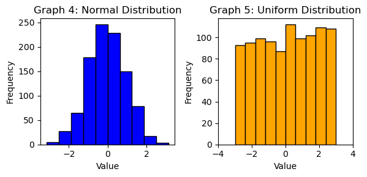

```python
#answer here:

#import anything you'll need to set up the histograms.
import numpy as np
import matplotlib.pyplot as plt
import pandas as pd

#Make fake samples to use in our histograms
normal_sample = np.random.normal(loc=0, scale=1, size=1000)
uniform_sample = np.random.uniform(low=-3, high=3, size=1000) #low is min, high is max

#set up the subplots
fig, subfig_array = plt.subplots(nrows = 1, ncols = 2, figsize= (6, 3))

#set up the first histogram
subfig_array[0].hist(normal_sample, color='blue', edgecolor='black')
subfig_array[0].set_title("Graph 4: Normal Distribution")
subfig_array[0].set_xlabel("Value")
subfig_array[0].set_ylabel("Frequency")
#Set up the second histogram
subfig_array[1].hist(uniform_sample, color='orange', edgecolor='black')
subfig_array[1].set_title("Graph 5: Uniform Distribution")
subfig_array[1].set_xlabel("Value")
subfig_array[1].set_ylabel("Frequency")

#adjust x-axis
plt.xlim(-4, 4)

#tight layout
plt.tight_layout()
plt.show()
```

Read in a .csv file to create a Pandas DataFrame. Create a scatter plot with one of the variables (or features) corresponding to the x-axis and another corresponding to the y-axis. The plot should have a title and labeled axes.

[figure not shown]

```python
#answer here:

#import what we need
import numpy as np
import matplotlib.pyplot as plt
import pandas as pd

#read the data we have in the csv file
korea_emissions = pd.read_csv("practice_quiz_data/korea_rep_co2_emissions.csv")

#Plot them using plt
plt.scatter(x = korea_emissions["year"], y = korea_emissions["total_emissions"], color='red')
plt.title("Graph 6: South Korea CO2 Emissions from 1960 to 2018")
plt.xlabel("Year")
plt.ylabel("Total Emissions (in million metric tons)")
plt.show()
```

Read in a .csv file to create a Pandas DataFrame. Loop over a list of variable/column names, printing the mean of each variable.

```python
#answer here:
import numpy as np
import matplotlib.pyplot as plt
import pandas as pd

#read a csv file
us_emissions = pd.read_csv("practice_quiz_data/united_states_co2_emissions.csv")

#assign it to a variable that matches the columns of the dataframe
columns = ["year", "total_emissions"]

#Set up the loop to print the mean of each variable
for column in columns:
    mean_value = us_emissions[column].mean()
    print("The mean of", column, "is", mean_value)
```

```
The mean of year is 1989.5
The mean of total_emissions is 4733944.143726562
```

Create a list of .csv file names and an additional empty list. Then in a for loop, read in each file to make a DataFrame, compute the mean of one of the variables/features/columns, and store it as an element of the originally empty list. Then print the list.

```python
#import
import numpy as np
import matplotlib.pyplot as plt
import pandas as pd

#create a csv file of the existing data
csv_files = ["practice_quiz_data/korea_rep_co2_emissions.csv", "practice_quiz_data/united_states_co2_emissions.csv"]

#set up an empty list
dataframes = []

#create the for loop to read each csv file and append it to the empty list
for file in csv_files:
    df = pd.read_csv(file) #reads the csv file
    mean_value = df["total_emissions"].mean() #calculates the mean of the total_emissions column
    dataframes.append(mean_value) #appends the mean value to the empty list

print(dataframes) #prints the list of mean values
```

```
[np.float64(287606.4942740235), np.float64(4733944.143726562)]
```